# Question Bank Interpretable Clustering

Author

Vojtěch Máčala

```python
import polars as pl
import plotly.express as px
import plotly
from itables import init_notebook_mode, show, options
```

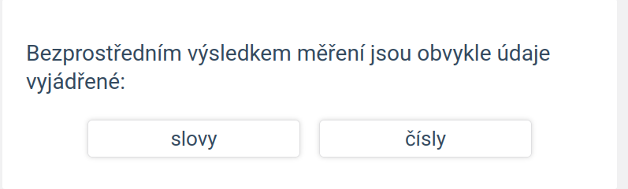

Příklad rozhodovačky

## 1) Cíl

Cíle

#### => Prozkoumat rozhodovačky v různých resource setech (RS)

#### => Vytvořit shluky otázek, které pomohou s:

- získáním přehledu o tématech v RS
- rozhodováním, která témata jsou málo zastoupená
- které otázky jsou špatně zařazené
- zda je potřeba okruhy rozdělit

```python
def safe_show_itable(filepath):
    try:
        if filepath.exists() and filepath.stat().st_size > 0:
            df = pl.read_csv(filepath)
            # Capture HTML representation for potential wrapping
            itable_html = show(df, classes="display compact")
            return itable_html
        else:
            print(f"<p><em>Data file not found or empty: {filepath.name}</em></p>")
            return ""
    except Exception as e:
        print(f"<p><em>Error loading data {filepath.name}: {e}</em></p>")
        return ""
```

## 2) Postup

[figure not shown]

Schema Bertopic pipeliny

```python
from pathlib import Path

results_dir = Path("./results/")
names = list(set(file.stem.split(".")[0] for file in results_dir.iterdir()))
```

## 3) Výsledky

### Kde to funguje

**prenos_dat**

[interactive chart not shown]

question

correct

distractor

rs_name

Topic

Name

successRate

[figure not shown]

**robotika**

[interactive chart not shown]

question

correct

distractor

rs_name

Topic

Name

successRate

[figure not shown]

**internet_web**

[interactive chart not shown]

question

correct

distractor

rs_name

Topic

Name

successRate

[figure not shown]

**digitalni_identita**

[interactive chart not shown]

question

correct

distractor

rs_name

Topic

Name

successRate

[figure not shown]

**operacni_systemy**

[interactive chart not shown]

question

correct

distractor

rs_name

Topic

Name

successRate

[figure not shown]

**hardware_pamet**

[interactive chart not shown]

question

correct

distractor

rs_name

Topic

Name

successRate

[figure not shown]

**historie_pocitacu**

[interactive chart not shown]

question

correct

distractor

rs_name

Topic

Name

successRate

[figure not shown]

**procesor_architektura**

[interactive chart not shown]

question

correct

distractor

rs_name

Topic

Name

successRate

[figure not shown]

**site_obecne**

[interactive chart not shown]

question

correct

distractor

rs_name

Topic

Name

successRate

[figure not shown]

**hesla_autentizace**

[interactive chart not shown]

question

correct

distractor

rs_name

Topic

Name

successRate

[figure not shown]

```python
from pathlib import Path

out_results_dir = Path("./outliers_results/")
out_results_names = list(set(file.stem.split(".")[0] for file in out_results_dir.iterdir()))
```

### Outliers

**prenos_dat**

[interactive chart not shown]

**robotika**

[interactive chart not shown]

**internet_web**

[interactive chart not shown]

**digitalni_identita**

[interactive chart not shown]

**operacni_systemy**

[interactive chart not shown]

**hardware_pamet**

[interactive chart not shown]

**historie_pocitacu**

[interactive chart not shown]

**procesor_architektura**

[interactive chart not shown]

**site_obecne**

[interactive chart not shown]

**hesla_autentizace**

[interactive chart not shown]

```python
from pathlib import Path

bad_results_dir = Path("./bad_results/")
bad_results_names = list(set(file.stem.split(".")[0] for file in bad_results_dir.iterdir()))
```

### Kde to nefunguje

**grafy_nejkratsi_cesty**

[interactive chart not shown]

question

correct

distractor

rs_name

Topic

Name

successRate

[figure not shown]

**priserky_urcovani_pravdivosti**

[interactive chart not shown]

question

correct

distractor

rs_name

Topic

Name

successRate

[figure not shown]

**slovni_vztahy**

[interactive chart not shown]

question

correct

distractor

rs_name

Topic

Name

successRate

[figure not shown]

**sloupcove_grafy**

[interactive chart not shown]

question

correct

distractor

rs_name

Topic

Name

successRate

[figure not shown]

**logicke_dusledky**

[interactive chart not shown]

question

correct

distractor

rs_name

Topic

Name

successRate

[figure not shown]

**ovoce_zelenina_urcovani_pravdivosti**

[interactive chart not shown]

question

correct

distractor

rs_name

Topic

Name

successRate

[figure not shown]

**histogramy**

[interactive chart not shown]

question

correct

distractor

rs_name

Topic

Name

successRate

[figure not shown]

**negace_tvrzeni**

[interactive chart not shown]

question

correct

distractor

rs_name

Topic

Name

successRate

[figure not shown]

## Výhody postupu

- spousta hyperparametrů, které se dají optimalizovat pro konkrétní data
- modularita - stačí definovat jednotlivé komponenty
- shluky jsou interpretovatelné
- výsledné reprezentace lze vylepšit pomocí jazykovych modelů
- lze použít v semi-supervised nastavení | *Guided Topic Modelling*
- *Online Topic Modelling*

## Limitace postupu

- spousta hyperparametrů
- hodně závisí na kvalitě embeddingů (čeština pokulhává)
- moc nefunguje pro příliš krátké texty
- ideální pro větší množství dokumentů
- defaultně hodně outlierů

[interactive chart not shown]

#### Možná doporučení

Wifi - bezdrátové sítě

###### V *sítě protokoly* je skupina otáze na wifi / bezdrátové sítě. V *sítě obecné* je taky několik otázek na wifi = může dávat smysl vytvořit nové resource set a přemístit do něj otázky z těchto dvou.

Procesor - hardware

###### V *Procesor architektura* je relativně malá skupina otázek na von Neumannovu architekturu - obecnější téma než architektura procesoru, dávalo by smysl přesunout tyto otázky do *Hardware zaklady*

Prohledávání stavového prostoru - optimalizace

###### V *Optimalizace* je skupina otázek ohledně prohledávání stavového prostoru. *Prohledávání stavového prostoru* je ale i vlastní resource set. Může dát smysl se zamyslet, jak velký průnik mezi tématy chceme.